# Reproducible Research - Project 1

### Question 1

It is important to ensure the working directory is correct and read in the file. In this case, we used the `read_csv()` which is party of the tidyverse package. Notice we loaded the library before reading in our data.

```r
getwd()
```

```
## [1] "/Users/christopherholman/Library/Mobile Documents/com~apple~CloudDocs/GitHub Projects/Reproducible-Research"
```

```r
library(tidyverse)
activity <- read_csv("./activity.csv")
activity_original <- activity

head(activity)
```

```
## # A tibble: 6 × 3
##   steps date       interval
##   <dbl> <date>        <dbl>
## 1    NA 2012-10-01        0
## 2    NA 2012-10-01        5
## 3    NA 2012-10-01       10
## 4    NA 2012-10-01       15
## 5    NA 2012-10-01       20
## 6    NA 2012-10-01       25
```

```r
str(activity)
```

```
## spec_tbl_df [17,568 × 3] (S3: spec_tbl_df/tbl_df/tbl/data.frame)
##  $ steps   : num [1:17568] NA NA NA NA NA NA NA NA NA NA ...
##  $ date    : Date[1:17568], format: "2012-10-01" "2012-10-01" ...
##  $ interval: num [1:17568] 0 5 10 15 20 25 30 35 40 45 ...
##  - attr(*, "spec")=
##   .. cols(
##   ..   steps = col_double(),
##   ..   date = col_date(format = ""),
##   ..   interval = col_double()
##   .. )
##  - attr(*, "problems")=<externalptr>
```

The variables included in this dataset are:

-steps: Number of steps taking in a 5-minute interval (missing values are coded as **NA**) -date: The date on which the measurement was taken in YYYY-MM-DD format -interval: Identifier for the 5-minute interval in which measurement was taken

```r
cleanActivity <- activity[!(is.na(activity$steps)),]
```

Aggregte steps by date

```r
dailyActivity <- aggregate(steps ~ date, cleanActivity, sum)
```

Creating a histogram for number of steps taken each day.

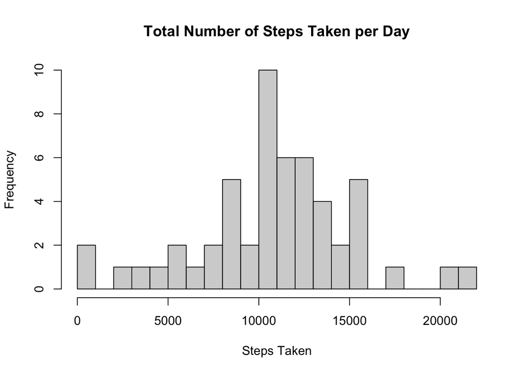

```r
hist(dailyActivity$steps, breaks = 20, xlab = "Steps Taken",
     main = "Total Number of Steps Taken per Day")
```

```r
library(xtable)
library(dplyr)
stepMean <- mean(dailyActivity$steps)
stepMedian <- median(dailyActivity$steps)
summary <- summary(dailyActivity)
```

To calculate the number of steps taken per interval, we need to aggregate by interval

```r
intervalActivity <- aggregate(steps ~ interval, cleanActivity, mean)
```

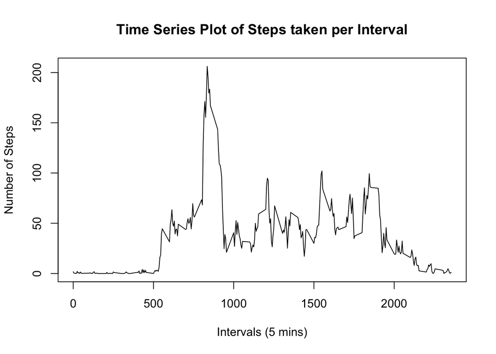

```r
stepPlot <- plot(x = intervalActivity$interval, y = intervalActivity$steps, type = "l",
         main = "Time Series Plot of Steps taken per Interval",
         ylab = "Number of Steps",
         xlab = "Intervals (5 mins)"
         )
```

```r
maxSteps <- intervalActivity[grep(max(intervalActivity$steps), intervalActivity$steps),]
```

### Question 4

Replace NA values in Steps with mean value for that interval

```r
imputedActivity <- activity
for(x in 1:17568){
    if(is.na(imputedActivity[x, 1])==TRUE){
        imputedActivity[x,1] <- intervalActivity[intervalActivity$interval %in% imputedActivity[x,3],2]
    }
}
```

Aggregate steps by day in the new data with imputed step values

```r
imputedActivityDailySteps <- aggregate(steps ~ date, imputedActivity, sum)
```

Create histogram of new imputed data.

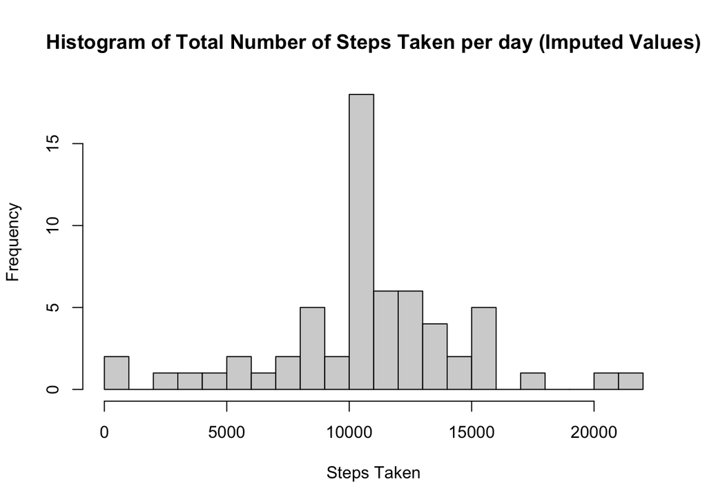

```r
hist(imputedActivityDailySteps$steps, breaks = 20,
     xlab = "Steps Taken",
     main = "Histogram of Total Number of Steps Taken per day (Imputed Values)")
```

```r
imputedStepsSummary <- summarise(imputedActivityDailySteps,
                 meanImputedSteps = mean(imputedActivityDailySteps$steps),
                 medianImputedSteps = median(imputedActivityDailySteps$steps))
```

## Question 5

To compare the average number of steps we must format a new variable to categorize the observation as part of the weekday or weekend.

```r
activityDays <- imputedActivity
activityDays$days <- weekdays(activityDays$date)
activityDays$weekday <- as.character(rep(0, times=17568))
for(x in 1:17568) {
    if(activityDays[x, 4] %in% c("Saturday", "Sunday")) {
        activityDays[x, 5] <- "weekend"
    } else {
        activityDays[x, 5] <- "weekday"
    }
}
activityDays$weekday <- factor(activityDays$weekday)
```

We can will separate the data into a weekday and weekend set.

```r
weekdayData <- activityDays[activityDays$weekday == "weekday",]
weekendData <- activityDays[activityDays$weekday == "weekend",]
```

Then group the data by interval by the average number of steps

```r
weekdayMean <- aggregate(steps ~ interval, weekdayData, mean)
weekendMean <- aggregate(steps ~ interval, weekendData, mean)
```

Last, create the final plot comparing the average number of steps taken per 5 min interval across weekdays and weekend.

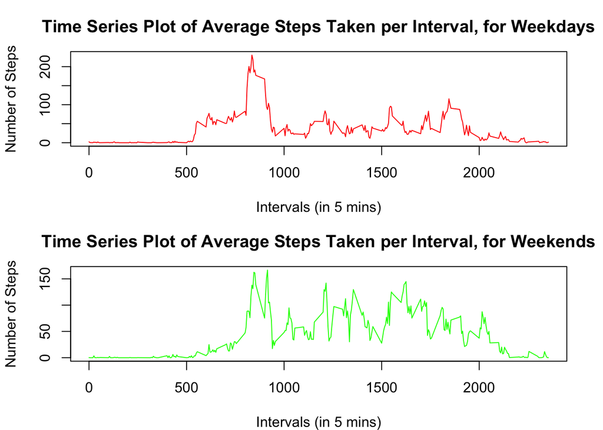

```r
par(mfrow=c(2, 1), mar=c(4, 4.1, 3, 2.1))
plot(weekdayMean$interval, weekdayMean$steps, type="l",
     main="Time Series Plot of Average Steps Taken per Interval, for Weekdays",
     xlab="Intervals (in 5 mins)", ylab="Number of Steps", col = "red")
plot(weekendMean$interval, weekendMean$steps, type="l",
     main="Time Series Plot of Average Steps Taken per Interval, for Weekends",
     xlab="Intervals (in 5 mins)", ylab="Number of Steps", col = "green")
```